# 23. Case study on survival analysis

dizhen

5/1/2020

```r
# library(Design)
library(mice)
library(foreign)
library(survival)
library(dplyr)
library(Hmisc)
```

Importation of SMART-data-file with correct variables and endpoints

```r
# Variables are already truncated to 1th en 99th percentiles
# SMART  <- read.spss('data/SMARTst.sav',use.value.labels=F, to.data.frame=T)

# Original SMARTfile not truncated
# SMARTo  <- read.spss('data/SMARTs.sav',use.value.labels=F, to.data.frame=T)
load("data/SMART.RData")
load("data/SMARTo.RData")
glimpse(SMART)
```

```
## Rows: 3,873
## Columns: 29
## $ TEVENT   <dbl> 3466, 3465, 3465, 2445, 3463, 1642, 991, 1970, 2623, 3131,...
## $ EVENT    <dbl> 0, 0, 0, 1, 0, 0, 1, 1, 1, 1, 0, 1, 1, 0, 0, 0, 0, 0, 0, 0...
## $ SEX      <dbl> 1, 2, 1, 1, 1, 2, 1, 1, 1, 1, 2, 2, 1, 1, 1, 2, 2, 1, 1, 1...
## $ AGE      <dbl> 71, 46, 59, 76, 57, 52, 66, 72, 75, 53, 40, 75, 63, 56, 66...
## $ DIABETES <dbl> 1, 0, 0, 0, 0, 1, 0, 0, 0, 1, 0, 0, 1, 0, 0, 0, 0, 0, 0, 0...
## $ CEREBRAL <dbl> 0, 0, 0, 0, 0, 0, 1, 0, 0, 0, 0, 0, 1, 0, 0, 0, 1, 1, 1, 1...
## $ CARDIAC  <dbl> 1, 0, 1, 1, 1, 0, 0, 1, 1, 0, 0, 0, 0, 0, 0, 0, 0, 0, 0, 0...
## $ AAA      <dbl> 0, 0, 0, 1, 0, 0, 1, 1, 0, 0, 0, 0, 0, 0, 1, 0, 0, 0, 0, 0...
## $ PERIPH   <dbl> 1, 1, 1, 1, 1, 1, 0, 0, 1, 1, 1, 1, 0, 1, 0, 1, 0, 0, 1, 1...
## $ STENOSIS <dbl> 0, 0, 0, 0, 0, 0, 1, 0, 1, 0, 0, 0, 1, 0, 1, 1, 1, 1, 0, 1...
## $ SYSTBP   <dbl> 185, 135, 149, 140, 177, 164, 166, 131, 175, 174, 144, 156...
## $ DIASTBP  <dbl> 86, 82, 97, 74, 96, 73, 70, 76, 68, 89, 84, 79, 86, 79, 83...
## $ SYSTH    <dbl> NA, NA, NA, NA, NA, NA, NA, NA, NA, NA, NA, NA, NA, NA, NA...
```

[output cut: 16 more lines]

```r
glimpse(SMARTo)
```

```
## Rows: 3,873
## Columns: 29
## $ TEVENT   <dbl> 3466, 3465, 3465, 2445, 3463, 1642, 991, 1970, 2623, 3131,...
## $ EVENT    <dbl> 0, 0, 0, 1, 0, 0, 1, 1, 1, 1, 0, 1, 1, 0, 0, 0, 0, 0, 0, 0...
## $ SEX      <dbl> 1, 2, 1, 1, 1, 2, 1, 1, 1, 1, 2, 2, 1, 1, 1, 2, 2, 1, 1, 1...
## $ AGE      <dbl> 71, 46, 59, 76, 57, 52, 66, 72, 75, 53, 40, 75, 63, 56, 66...
## $ DIABETES <dbl> 1, 0, 0, 0, 0, 1, 0, 0, 0, 1, 0, 0, 1, 0, 0, 0, 0, 0, 0, 0...
## $ CEREBRAL <dbl> 0, 0, 0, 0, 0, 0, 1, 0, 0, 0, 0, 0, 1, 0, 0, 0, 1, 1, 1, 1...
## $ CARDIAC  <dbl> 1, 0, 1, 1, 1, 0, 0, 1, 1, 0, 0, 0, 0, 0, 0, 0, 0, 0, 0, 0...
## $ AAA      <dbl> 0, 0, 0, 1, 0, 0, 1, 1, 0, 0, 0, 0, 0, 0, 1, 0, 0, 0, 0, 0...
## $ PERIPH   <dbl> 1, 1, 1, 1, 1, 1, 0, 0, 1, 1, 1, 1, 0, 1, 0, 1, 0, 0, 1, 1...
## $ STENOSIS <dbl> 0, 0, 0, 0, 0, 0, 1, 0, 1, 0, 0, 0, 1, 0, 1, 1, 1, 1, 0, 1...
## $ SYSTBP   <dbl> 185, 135, 149, 140, 177, 164, 166, 131, 175, 174, 144, 156...
## $ DIASTBP  <dbl> 86, 82, 97, 74, 96, 73, 70, 76, 68, 89, 84, 79, 86, 79, 83...
## $ SYSTH    <dbl> NA, NA, NA, NA, NA, NA, NA, NA, NA, NA, NA, NA, NA, NA, NA...
```

[output cut: 16 more lines]

## PAPER STEP 1: Data Inspection

```r
# Understand the data
SMART[1,]
```

```
##   TEVENT EVENT SEX AGE DIABETES CEREBRAL CARDIAC AAA PERIPH STENOSIS SYSTBP
## 1   3466     0   1  71        1        0       1   0      1        0    185
##   DIASTBP SYSTH DIASTH LENGTH WEIGHT   BMI CHOL  HDL  LDL TRIG HOMOC GLUT CREAT
## 1      86    NA     NA    1.7     69 23.88    6 0.94 4.03 2.29    NA  6.3    95
##    IMT albumin SMOKING packyrs alcohol
## 1 0.82       1       2    22.5       3
```

```r
dim(SMART)
```

```
## [1] 3873   29
```

```r
describe(SMART)
```

```
## SMART
##
##  29  Variables      3873  Observations
## --------------------------------------------------------------------------------
## TEVENT
##        n  missing distinct     Info     Mean      Gmd      .05      .10
##     3873        0     1934        1     1370     1078     98.6    197.0
##      .25      .50      .75      .90      .95
##    555.0   1213.0   2165.0   2762.4   3017.4
##
## lowest :    0.1    1.0    2.0    3.0    4.0, highest: 3451.0 3452.0 3463.0 3465.0 3466.0
## --------------------------------------------------------------------------------
## EVENT
##        n  missing distinct     Info      Sum     Mean      Gmd
##     3873        0        2    0.314      460   0.1188   0.2094
##
## --------------------------------------------------------------------------------
## SEX
##        n  missing distinct     Info     Mean      Gmd
##     3873        0        2    0.565    1.252   0.3771
##
## Value          1     2
## Frequency   2897   976
## Proportion 0.748 0.252
## --------------------------------------------------------------------------------
## AGE
##        n  missing distinct     Info     Mean      Gmd      .05      .10
##     3873        0       62    0.999    59.56    11.94       41       46
##      .25      .50      .75      .90      .95
##       52       60       68       73       76
##
## lowest : 19 20 23 24 25, highest: 78 79 80 81 82
## --------------------------------------------------------------------------------
## DIABETES
##        n  missing distinct     Info      Sum     Mean      Gmd
##     3833       40        2    0.516      846   0.2207   0.3441
##
## --------------------------------------------------------------------------------
## CEREBRAL
##        n  missing distinct     Info      Sum     Mean      Gmd
```

[output cut: 160 more lines]

```
##        n  missing distinct     Info     Mean      Gmd      .05      .10
##     3852       21      263    0.994    22.62    22.26      0.0      0.0
##      .25      .50      .75      .90      .95
##      5.9     19.5     34.2     50.4     62.0
##
## lowest :   0.0   0.3   0.6   0.7   0.8, highest: 100.0 102.0 104.0 110.0 120.0
## --------------------------------------------------------------------------------
## alcohol
##        n  missing distinct     Info     Mean      Gmd
##     3848       25        3     0.65    2.504   0.7353
##
## Value          1     2     3
## Frequency    751   408  2689
## Proportion 0.195 0.106 0.699
## --------------------------------------------------------------------------------
```

```r
# Generate an extra window for 1 plot
par(mfrow=c(1,1))

# Selecting 18 variables out of 29 in the loaded SMART-file and immediatly retrieve info again.
SMARTm <- SMART[,c("SYSTBP", "DIASTBP", "SYSTH", "DIASTH","CHOL","HDL",
                   "LDL","TRIG", "HOMOC", "GLUT", "CREAT", "IMT", "albumin",
                   "STENOSIS", "DIABETES", "SMOKING", "packyrs", "alcohol")]
describe(SMARTm)
```

```
## SMARTm
##
##  18  Variables      3873  Observations
## --------------------------------------------------------------------------------
## SYSTBP
##        n  missing distinct     Info     Mean      Gmd      .05      .10
##     2650     1223      114        1    141.3    22.41      112      117
##      .25      .50      .75      .90      .95
##      127      139      154      169      178
##
## lowest :  96  97  98  99 100, highest: 206 209 211 212 216
## --------------------------------------------------------------------------------
## DIASTBP
##        n  missing distinct     Info     Mean      Gmd      .05      .10
##     2652     1221       70    0.999     79.7    11.03       65       68
##      .25      .50      .75      .90      .95
##       73       79       86       93       97
##
## lowest :  46  48  52  53  54, highest: 117 118 120 124 127
## --------------------------------------------------------------------------------
## SYSTH
##        n  missing distinct     Info     Mean      Gmd      .05      .10
##     2375     1498      132        1    142.2    24.91    110.0    116.0
##      .25      .50      .75      .90      .95
##    126.0    140.0    156.0    172.0    182.3
##
## lowest :  79  88  91  93  94, highest: 222 223 228 242 244
## --------------------------------------------------------------------------------
## DIASTH
##        n  missing distinct     Info     Mean      Gmd      .05      .10
##     2374     1499       77    0.999    82.44    13.22       64       68
##      .25      .50      .75      .90      .95
##       75       82       90       98      103
##
## lowest :  45  49  50  52  53, highest: 123 125 126 130 136
## --------------------------------------------------------------------------------
## CHOL
##        n  missing distinct     Info     Mean      Gmd      .05      .10
##     3855       18       65    0.999    5.191    1.283      3.5      3.8
##      .25      .50      .75      .90      .95
```

[output cut: 87 more lines]

```
##        n  missing distinct     Info     Mean      Gmd      .05      .10
##     3852       21      263    0.994    22.62    22.26      0.0      0.0
##      .25      .50      .75      .90      .95
##      5.9     19.5     34.2     50.4     62.0
##
## lowest :   0.0   0.3   0.6   0.7   0.8, highest: 100.0 102.0 104.0 110.0 120.0
## --------------------------------------------------------------------------------
## alcohol
##        n  missing distinct     Info     Mean      Gmd
##     3848       25        3     0.65    2.504   0.7353
##
## Value          1     2     3
## Frequency    751   408  2689
## Proportion 0.195 0.106 0.699
## --------------------------------------------------------------------------------
```

### Cluster analysis of patterns of missingness

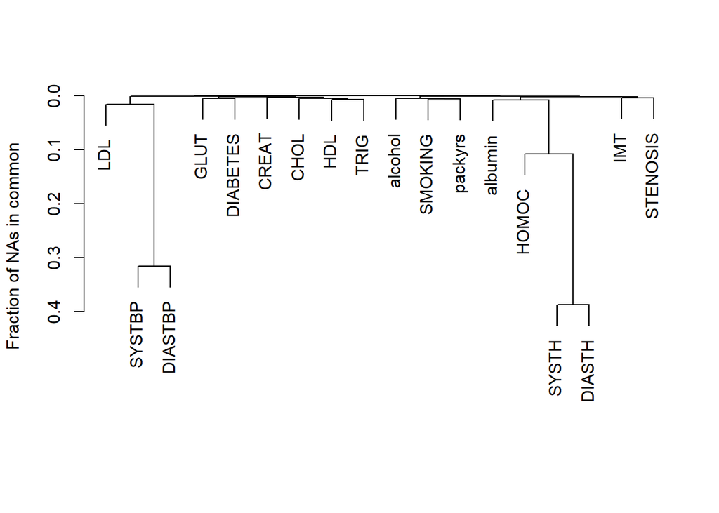

```r
# With the following function you determine the fraction of NA's (missing values)
# Cluster analysis of patterns of missingness in the SMART study (n = 3873)

na.patterns <- naclus(SMARTm)
# Plot the 18 variables you just selected in a graph
plot(na.patterns, ylab="Fraction of NAs in common")
```

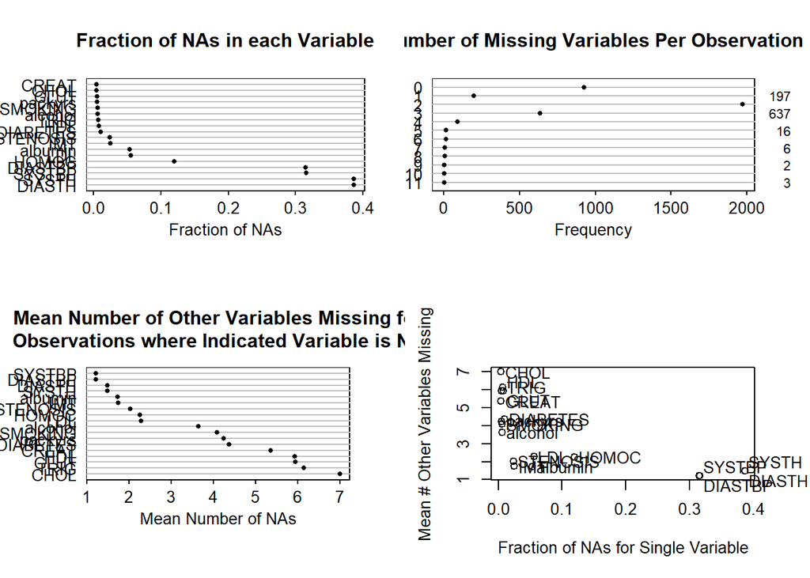

```r
# A different approach to show the NA's is the following:
# Patterns of missing data in the SMART study.

par(mfrow=c(2,2))
naplot(na.patterns, which=c('na per var'))
naplot(na.patterns, which=c('na per obs'))
naplot(na.patterns, which=c('mean na'))
naplot(na.patterns, which=c('na per var vs mean na'))
```

### Multiple imputation

```r
# (though multiple imputation is preferable from a theoretical view point, single imputation was considered more practical and sufficient to obtain reasonable predictions.)

(fmla <- as.formula(paste(" ~ ", paste(colnames(SMARTm), collapse=" +"))))
```

```
## ~SYSTBP + DIASTBP + SYSTH + DIASTH + CHOL + HDL + LDL + TRIG +
##     HOMOC + GLUT + CREAT + IMT + albumin + STENOSIS + DIABETES +
##     SMOKING + packyrs + alcohol
```

```r
a <- aregImpute(fmla, n.impute = 2,nk=0, data = SMARTm)
```

```
## Iteration 1
Iteration 2
Iteration 3
Iteration 4
Iteration 5
```

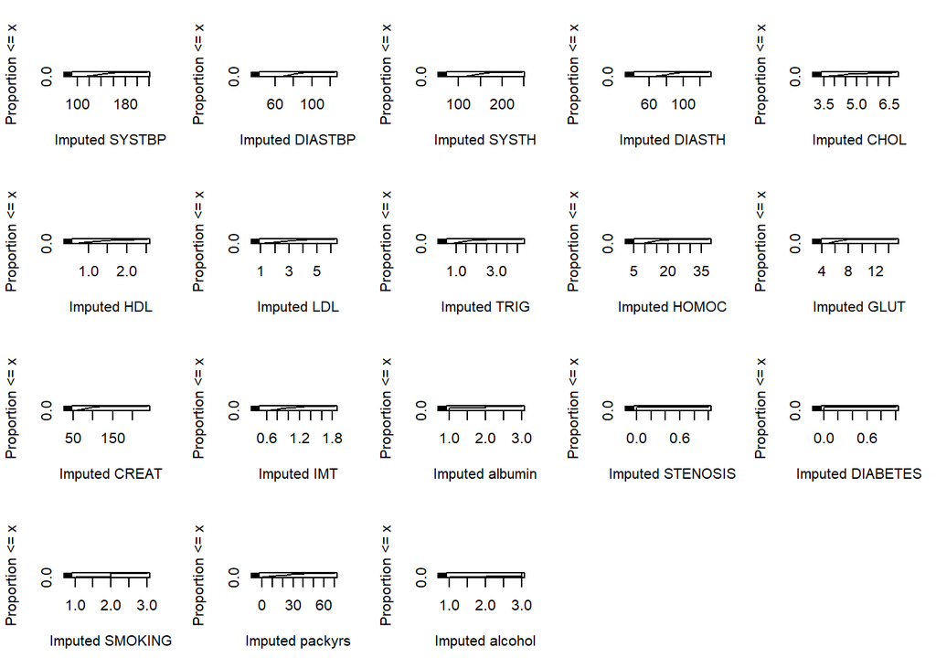

```r
# It is difficult to know selection with descrete. You have to force your variables to act linearly(nk=0) or force selected variables to be linear using I(xj).

par(mfrow=c(4,5))
plot(a)
```

```r
# Multiple imputation

# SMARTm <- SMART[,c("SYSTBP", "DIASTBP", "SYSTH", "DIASTH","CHOL","HDL",
                   # "LDL","TRIG", "HOMOC", "GLUT", "CREAT", "IMT", "albumin",
                   # "STENOSIS", "DIABETES", "SMOKING", "packyrs", "alcohol")]
imputed <-impute.transcan(a, data=SMART, imputation=1, list.out=TRUE, pr=FALSE, check=FALSE)


SMART[names(imputed)] <- imputed
head(SMART)
```

```
##   TEVENT EVENT SEX AGE DIABETES CEREBRAL CARDIAC AAA PERIPH STENOSIS SYSTBP
## 1   3466     0   1  71        1        0       1   0      1        0    185
## 2   3465     0   2  46        0        0       0   0      1        0    135
## 3   3465     0   1  59        0        0       1   0      1        0    149
## 4   2445     1   1  76        0        0       1   1      1        0    140
## 5   3463     0   1  57        0        0       1   0      1        0    177
## 6   1642     0   2  52        1        0       0   0      1        0    164
##   DIASTBP SYSTH DIASTH LENGTH WEIGHT   BMI CHOL  HDL  LDL TRIG HOMOC GLUT CREAT
## 1      86   168     88   1.70     69 23.88  6.0 0.94 4.03 2.29  14.3  6.3    95
## 2      82   129     76   1.72     71 24.00  4.0 1.26 2.23 1.13   8.7  4.7    66
## 3      97   131     89   1.77     82 26.17  4.9 1.28 3.17 1.01   9.3  6.1    93
## 4      74   132     70   1.82     98 29.59  5.3 1.00 3.40 2.01  11.8  5.0    79
## 5      96   131     87   1.90    107 29.64  5.2 0.81 2.41 4.76  27.1  6.1    91
## 6      73   165     92   1.73    103 34.41  4.6 0.95 2.38 2.82  27.5 10.2   180
##    IMT albumin SMOKING packyrs alcohol
## 1 0.82       1       2    22.5       3
## 2 0.57       1       1     0.0       1
## 3 0.83       1       2    33.3       3
## 4 1.45       2       2    49.0       3
## 5 1.07       1       2    53.2       3
## 6 0.97       3       2    54.6       1
```

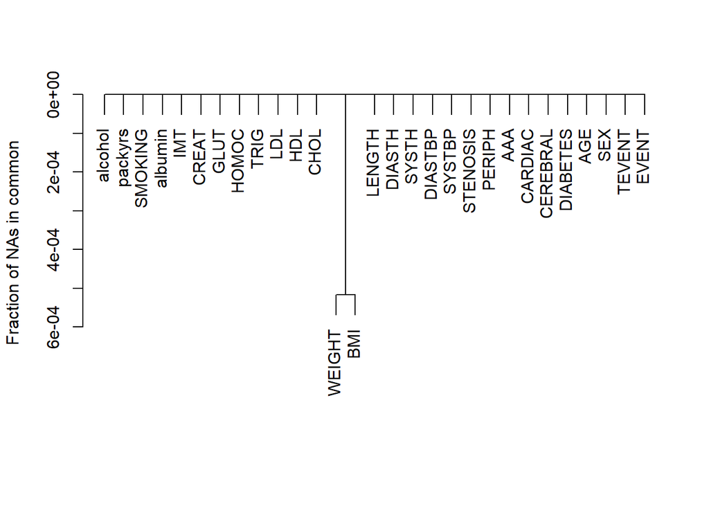

```r
na.patterns <- naclus(SMART)
# Plot the 18 variables you just selected in a graph
plot(na.patterns, ylab="Fraction of NAs in common")
```

## PAPER STEP 2: Coding of Predictors.

We used the Cox regression model. This model is appropriate for prediction of an outcome at relatively short-term such as 5 year cumulative incidence of cardiovascular events. For long-term predictions (e.g. 10 year incidences), a parametric model might be preferable such as a Weibull model. A Weibull model provides more stable estimates at the end of the follow-up.

### Extreme Values

Before any modelling started, the distributio of all potential predictors were carefully examined for extreme values. Biologically implausible values were set to missing values, and remaining extreme values were truncated by shifting the values below the 1 centile and above the 99 centile to “truncation points”.

```r
# Showing the maximum value of IMT in the truncated file.
max(SMART$IMT,na.rm=T)
```

```
## [1] 1.83
```

```r
# Show how many times this maximum value is exceeded in the original file
sum(SMARTo$IMTO>1.83,na.rm=T)
```

```
## [1] 51
```

```r
# Same, but now for the minimum value
min(SMART$IMT,na.rm=T)
```

```
## [1] 0.47
```

```r
sum(SMARTo$IMTO<.47,na.rm=T)
```

```
## [1] 13
```

```r
# show relation between IMT in both the not-truncated file and the truncated file with the cox proportional hazard function
coxph(Surv(TEVENT,EVENT) ~ IMT, data=SMART)
```

```
## Call:
## coxph(formula = Surv(TEVENT, EVENT) ~ IMT, data = SMART)
##
##       coef exp(coef) se(coef)     z      p
## IMT 1.2998    3.6684   0.1458 8.916 <2e-16
##
## Likelihood ratio test=70.89  on 1 df, p=< 2.2e-16
## n= 3873, number of events= 460
```

```r
coxph(Surv(TEVENT,EVENT) ~  IMTO, data=SMARTo)
```

```
## Call:
## coxph(formula = Surv(TEVENT, EVENT) ~ IMTO, data = SMARTo)
##
##         coef exp(coef) se(coef)     z      p
## IMTO 0.91167   2.48846  0.09542 9.554 <2e-16
##
## Likelihood ratio test=60.5  on 1 df, p=7.349e-15
## n= 3775, number of events= 446
##    (98 observations deleted due to missingness)
```

```r
library(rms)
library(survminer)
library(riskRegression)
```

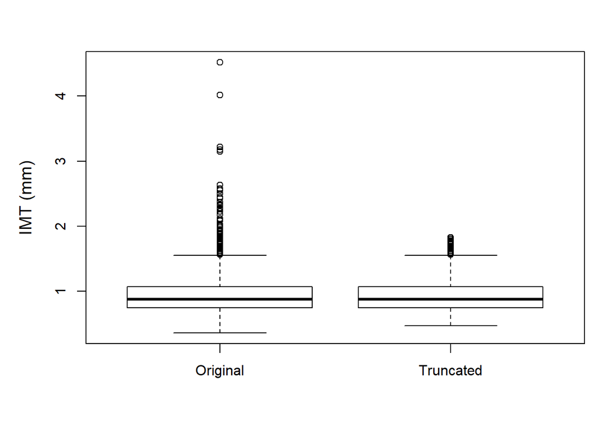

```r
# again an extra screen
par(mfrow=c(1,1),mar=c(5,5,3,1))

# boxdf <- data.frame(Truncated = SMART$IMT, Origianl = SMARTo$IMTO)
# boxplot(boxdf, ylab = "IMT (mm)")

# make an new matrix with the the original and truncated IMT variable. Then name the two colums
IMTdata <- as.matrix(cbind(SMARTo$IMTO, SMART$IMT))
IMTlist <- split(IMTdata, col(IMTdata))
names(IMTlist)  <- Cs(Original, Truncated)
# make a boxplot of this matirx to show the difference of the data when it's truncated
boxplot(IMTlist, ylab= "IMT (mm)", cex.lab=1.2)
```

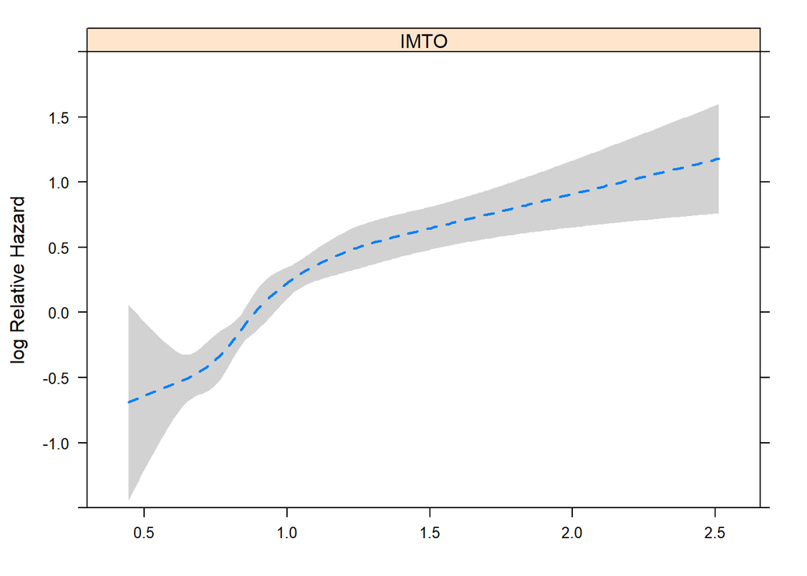

```r
# Now the effect on outcome is shown with the cph-function in three ways
#to show how the variable which fit the model best:
#1: Not truncated with restricted cubic spline with 5 knots
dd <- datadist(SMARTo)
options(datadist="dd")
IMTOfit <- cph(Surv(TEVENT,EVENT) ~  rcs(IMTO,5), data=SMARTo)
pred1 <- Predict(IMTOfit)
plot(pred1, xlab="IMT (mm)", lty=2, lwd=2, conf.int=F)
```

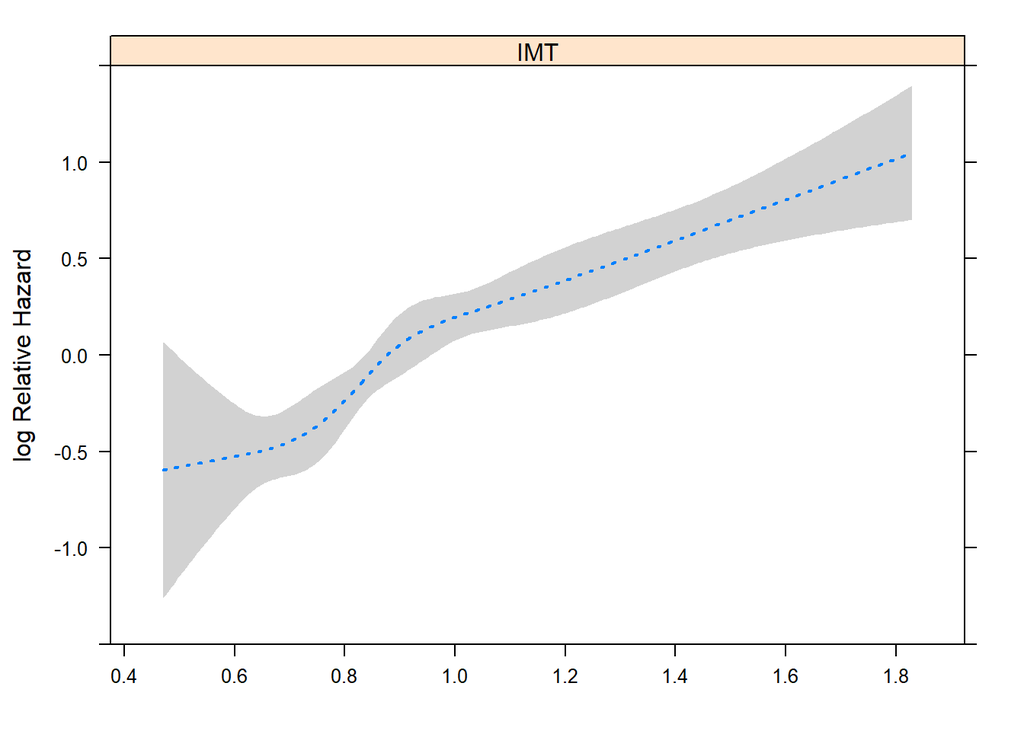

```r
# plot(Predict(IMTOfit), xlab="IMT (mm)", lty=2, lwd=2, conf.int=F)
pred1$type <- rep("IMTO",length(Predict(IMTOfit)[,1]))

#2: Truncated with restricted cubic spline with 5 knots
dd <- datadist(SMART)
options(datadist="dd")
IMTfit <- cph(Surv(TEVENT,EVENT) ~  rcs(IMT,5), data=SMART)
pred2 <- Predict(IMTfit)
plot(pred2, xlab="", lty=3, lwd=2,conf.int=F)
```

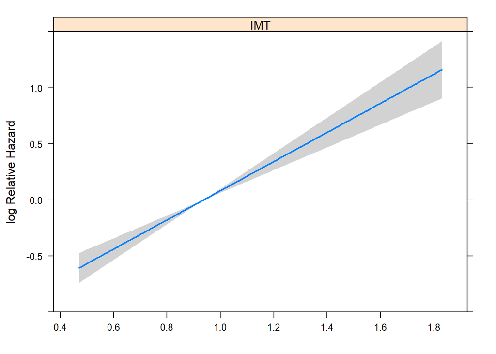

```r
pred2$type <- rep("IMT",length(Predict(IMTfit)[,1]))

#3: Truncated linear
IMTfitlin <- cph(Surv(TEVENT,EVENT) ~  IMT, data=SMART)
pred3 <- Predict(IMTfitlin)
plot(pred3, xlab="",  lty=1, lwd=2, conf.int=F)
```

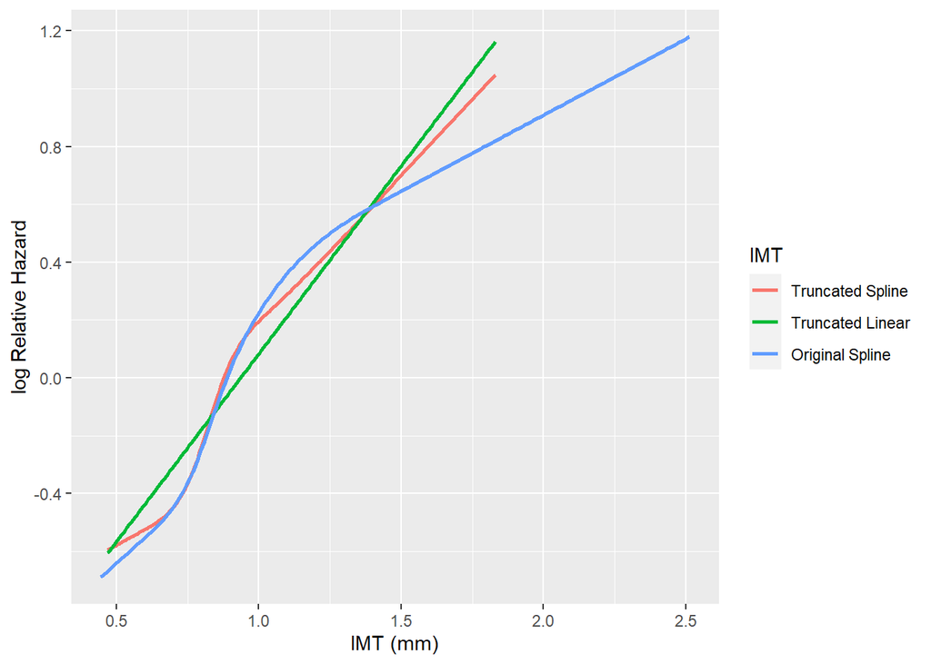

```r
pred3$type <- rep("IMTlin",length(Predict(IMTfitlin)[,1]))


names(pred1) <- c("x","yhat","lower","upper",".predictor.","type")
names(pred2) <- c("x","yhat","lower","upper",".predictor.","type")
names(pred3) <- c("x","yhat","lower","upper",".predictor.","type")
preddf <- rbind(pred1, pred2, pred3)[,c(1:6)]
preddf <- as.data.frame(preddf)
ggplot(preddf, aes(x = x, y = yhat, color = type)) +
  geom_line( lwd=1)+
  labs(x = "IMT (mm)", y = "log Relative Hazard")+
  scale_color_discrete(name = "IMT", labels = c("Truncated Spline", "Truncated Linear", "Original Spline"))
```

### Transforming continuous predictors

We consider several transformations of variables. Based on the Wald $\chi^2$, we know how the model fit or the performance with those covariates.

Results: A transformation such as (Age-50)^2+ led to an better model with $chi^2 = 130$. For creatinine, a log transformation gave the best fit. A linear coding of systolic blood pressure was reasonable and diastolic blood pressure had no effect when we analyzed the convertional sphygmomanometry blood pressure measurements (“SYSTH” and “DIASTH” variables).

Start of Age example.

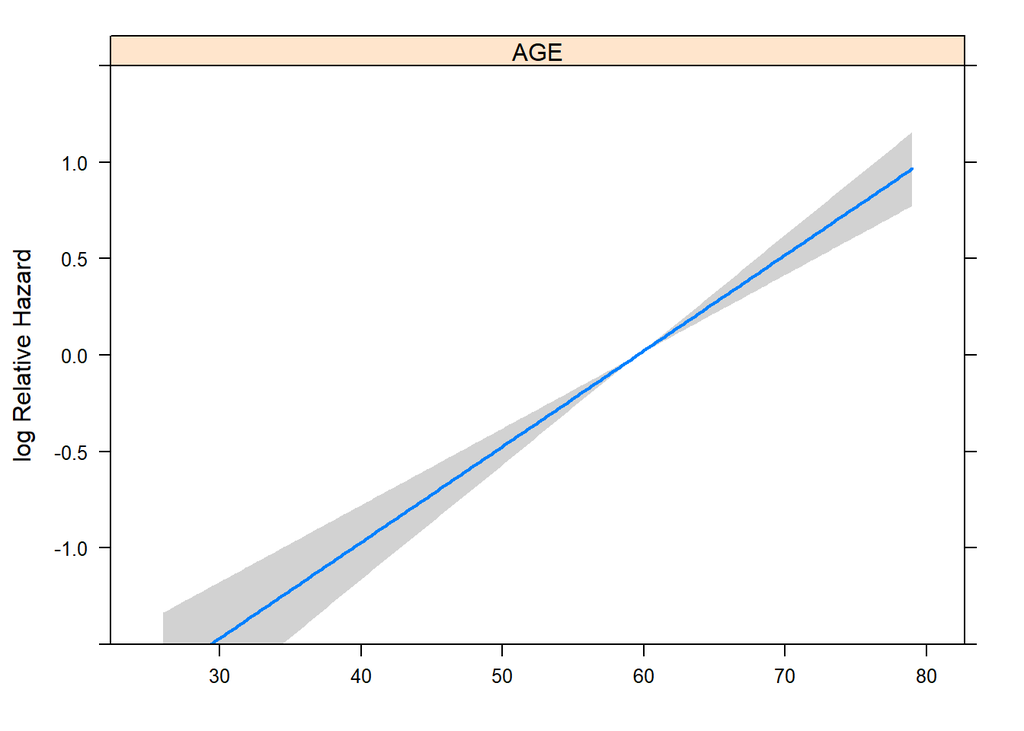

```r
# Example transformation of age to get best fit.
# With cph-function the X2 and dof are measured when the variable in transformed.
dd <- datadist(SMART)
options(datadist="dd")
# par(mfrow=c(2,2), mar=c(5,5,3,1))
# par(mfrow=c(1,1))
# age related to outcome: age linear --> X2=97
AGEfit <- cph(Surv(TEVENT,EVENT) ~  AGE, data=SMART)
plot(Predict(AGEfit),
     xlab="Age (years)", ylab = "log Relative Hazard",
     lty=1, lwd=2,conf.int=T,
     ylim=c(-1.5, 1.5), xlim=c(20,80))
```

```r
df1 <- Predict(AGEfit)
df1 <- df1 %>% mutate(type = rep(1,length(df1[,1])))
anova(AGEfit)
```

```
##                 Wald Statistics          Response: Surv(TEVENT, EVENT)
##
##  Factor     Chi-Square d.f. P
##  AGE        97.17      1    <.0001
##  TOTAL      97.17      1    <.0001
```

```r
# age related to outcome: age + age squared --> X2= 125
AGEfit2 <- cph(Surv(TEVENT,EVENT) ~  pol(AGE,2), data=SMART)  # age + age squared
df2 <- Predict(AGEfit2)
df2 <- df2 %>% mutate(type = rep(2,length(df2[,1])))
anova(AGEfit2)
```

```
##                 Wald Statistics          Response: Surv(TEVENT, EVENT)
##
##  Factor     Chi-Square d.f. P
##  AGE        124.99     2    <.0001
##   Nonlinear  15.00     1    1e-04
##  TOTAL      124.99     2    <.0001
```

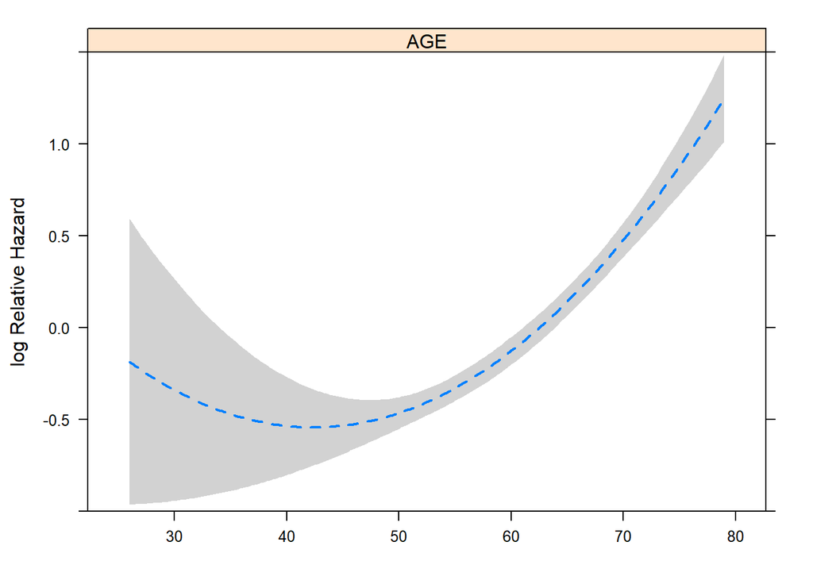

```r
plot(Predict(AGEfit2),
     xlab="Age (years)", ylab = "log Relative Hazard",
     lty=2, lwd=2,conf.int=T
     )
```

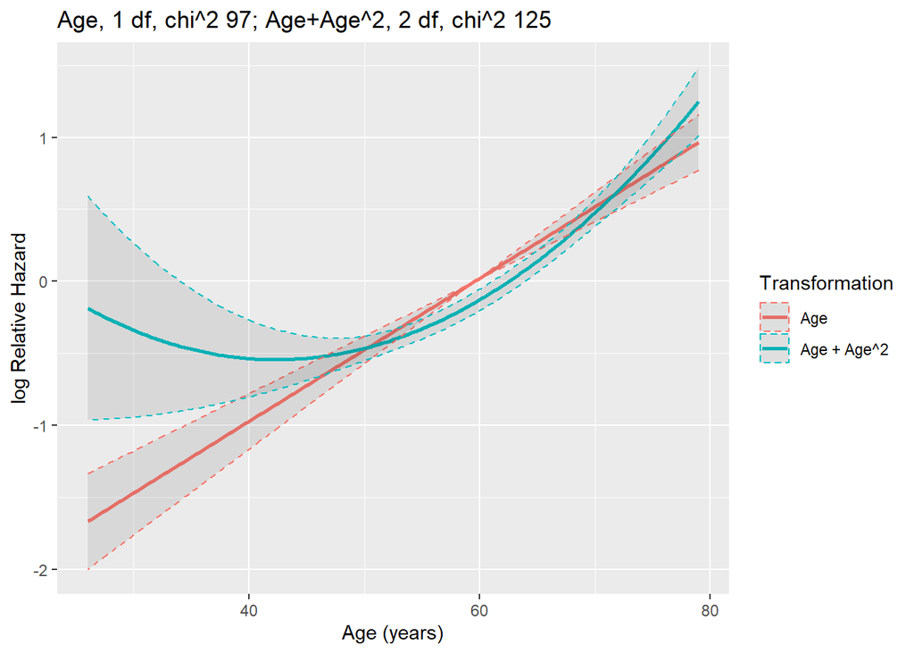

```r
plotdf <- rbind(df1, df2)

plotdf %>%ggplot(aes(x = AGE, y = yhat, color = factor(type))) +
  geom_line(lwd=1)+
  # geom_point() +
  geom_ribbon(aes(ymin=lower, ymax=upper), linetype=2, alpha=0.1)+
  labs(title = paste("Age, 1 df, ", "chi^2"," ", 97, "; Age+","Age^2",", 2 df, ", "chi^2"," ", 125,sep=""),
       y = "log Relative Hazard",
       x = "Age (years)")+
  scale_color_discrete(name = "Transformation", labels = c("Age", "Age + Age^2"))
```

```r
# Age related to outcome: 125truncated under 50 / 55 and then linear --> X2= 119
AGEfit3 <- cph(Surv(TEVENT,EVENT) ~  ifelse(AGE>55, (AGE-55),0), data=SMART)  # age linear
anova(AGEfit3)
```

```
##                 Wald Statistics          Response: Surv(TEVENT, EVENT)
##
##  Factor     Chi-Square d.f. P
##  AGE        118.59     1    <.0001
##  TOTAL      118.59     1    <.0001
```

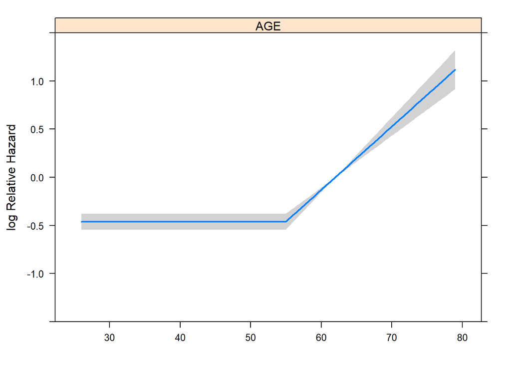

```r
df3 <- Predict(AGEfit3)
df3 <- df3 %>% mutate(type = rep(3, length(df3[,1])))
plot(Predict(AGEfit3),
     xlab="Age (years)",ylab = "log Relative Hazard",
     lty=1, lwd=2,conf.int=T,
     ylim=c(-1.5, 1.5), xlim=c(20,80))
```

```r
# Age related to outcome: 125truncated under 50 / 55 and then squared --> X2= 130
AGEfit4 <- cph(Surv(TEVENT,EVENT) ~  ifelse(AGE>50, (AGE-50)^2,0), data=SMART)  # age + age squared
anova(AGEfit4)
```

```
##                 Wald Statistics          Response: Surv(TEVENT, EVENT)
##
##  Factor     Chi-Square d.f. P
##  AGE        129.64     1    <.0001
##  TOTAL      129.64     1    <.0001
```

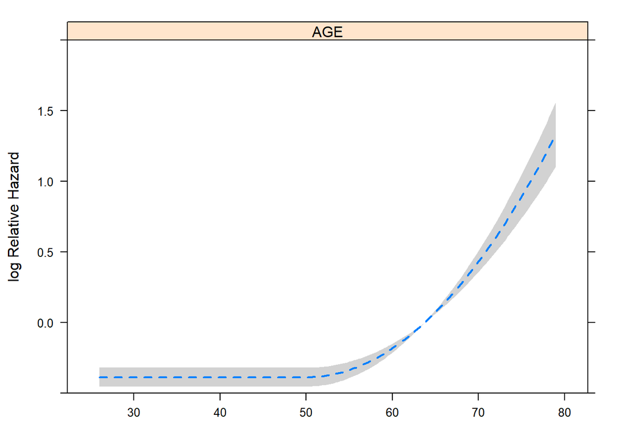

```r
df4 <- Predict(AGEfit4)
df4 <-df4 %>% mutate(type = rep(4, length(df4[,1])))
plot(Predict(AGEfit4),
     xlab="Age (years)", ylab = "log Relative Hazard",
     lty=2, lwd=2,conf.int=T)
```

[figure not shown]

```r
plotdf <- rbind(df3, df4)

plotdf %>%ggplot(aes(x = AGE, y = yhat, color = factor(type))) +
  geom_line(lwd=1)+
  # geom_point() +
  geom_ribbon(aes(ymin=lower, ymax=upper), linetype=2, alpha=0.1)+
  labs(title = paste("Age>55, 1 df, ", "chi^2"," ", 119, "; ","(Age>50)^2",", 2 df, "," chi^2"," ", 130,sep=""),
       x = "Age (years)",
       y = "log Relative Hazard")+
  scale_color_discrete(name = "Transformation", labels = c("Age>55", "(Age>50)^2"))
```

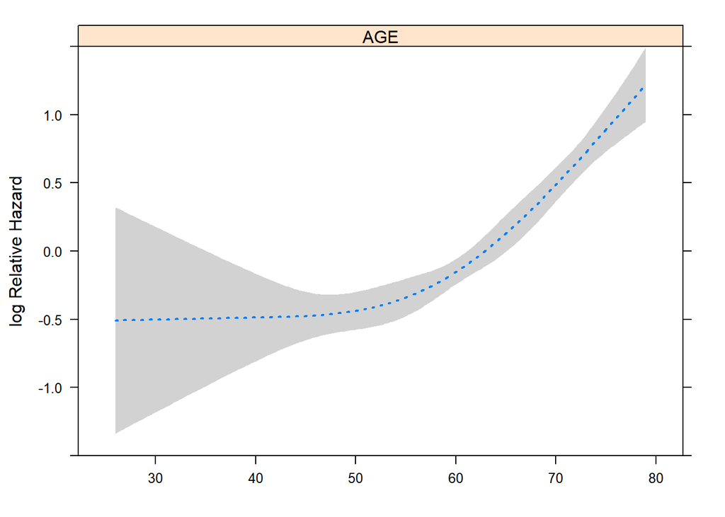

```r
# age related to outcome with Spline and 3 df (4 knots) --> X2=125
AGEfit5 <- cph(Surv(TEVENT,EVENT) ~  rcs(AGE,4), data=SMART)
anovaAge  <- anova(AGEfit5)
plot(Predict(AGEfit5), xlab="Age (years)", lty=3, lwd=2,conf.int=T,
     ylim=c(-1.5, 1.5), xlim=c(20,80))
```

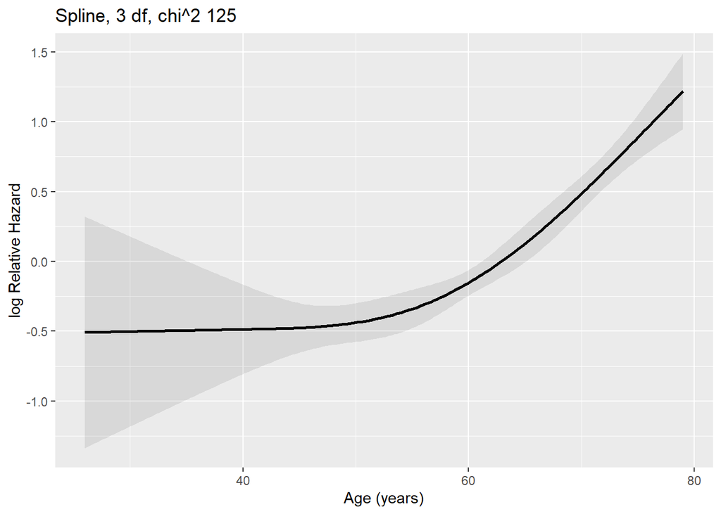

```r
# title(substitute(paste("Spline, 3 df, ", "chi^2"," ", 125,sep="")), cex.main=1)
plotdf <- as.data.frame(Predict(AGEfit5))

plotdf %>% ggplot(aes(x = AGE, y = yhat)) +
  geom_line(lwd=1)+
  # geom_point() +
  geom_ribbon(aes(ymin=lower, ymax=upper), linetype=2, alpha=0.1)+
  labs(title = paste("Spline, 3 df, ", "chi^2"," ", 125,sep=""),
       x = "Age (years)",
       y = "log Relative Hazard")
```

```r
# Age related to outcome in quartiles --> X2=93
tapply(SMART$AGE, ifelse(SMART$AGE<50,1,ifelse(SMART$AGE<60,2,ifelse(SMART$AGE<70,3,4))), mean)
```

```
##        1        2        3        4
## 43.20362 54.78531 64.53566 73.59654
```

```r
SMART$AGEcat  <- as.factor(ifelse(SMART$AGE<50,43,ifelse(SMART$AGE<60,55,ifelse(SMART$AGE<70,65,74))))
# SMART$AGEcat <- as.factor(SMART$AGEcat)
dd <- datadist(SMART)
options(datadist="dd")
AGEfit6 <- cph(Surv(TEVENT,EVENT) ~  AGEcat, data=SMART)

anova (AGEfit6)
```

```
##                 Wald Statistics          Response: Surv(TEVENT, EVENT)
##
##  Factor     Chi-Square d.f. P
##  AGEcat     93.22      3    <.0001
##  TOTAL      93.22      3    <.0001
```

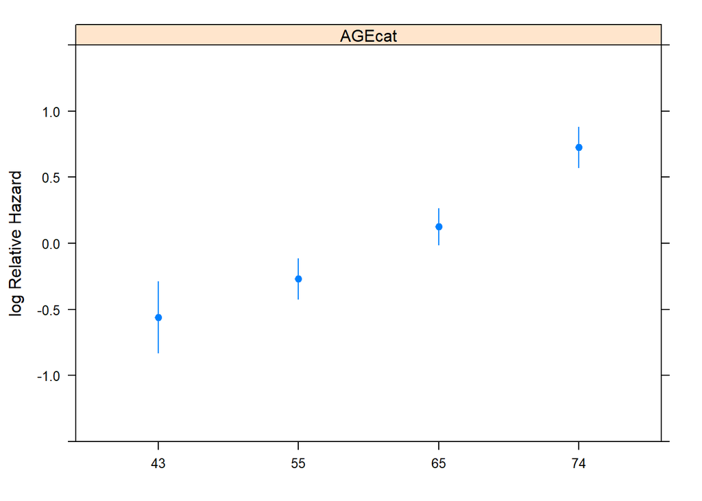

```r
plotdf <- as.data.frame(Predict(AGEfit6))
plot(Predict(AGEfit6),
     xlab="Age (years)", ylab = "log Relative Hazard",
     lty=3, lwd=2,conf.int=T,
     ylim=c(-1.5, 1.5))
```

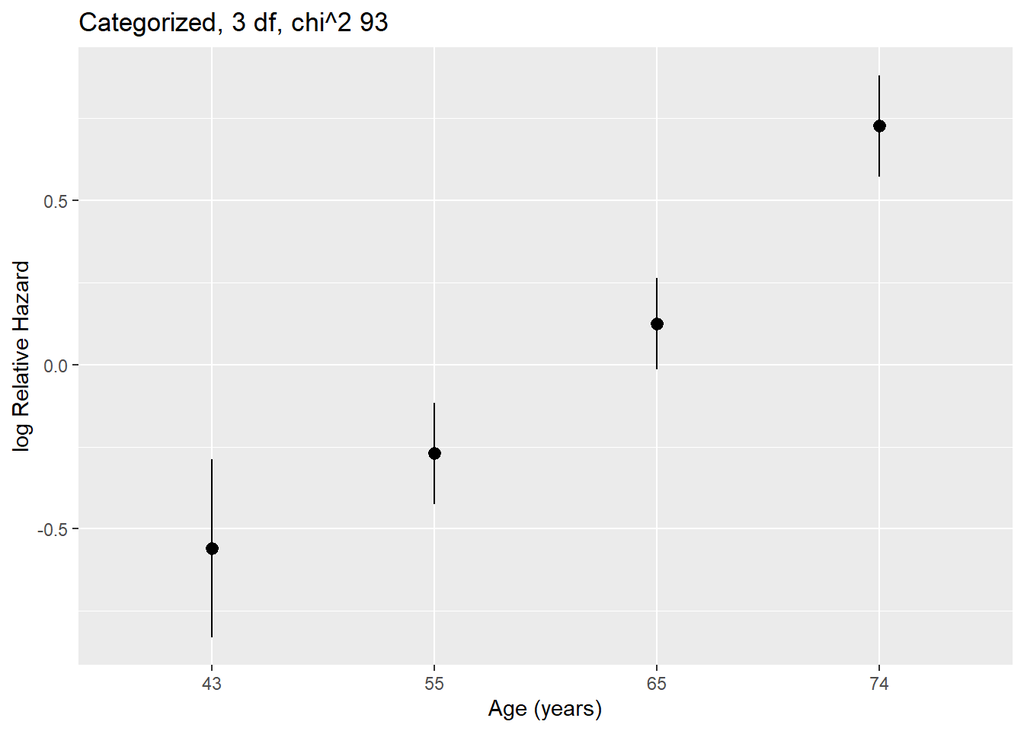

```r
# title(substitute(paste("Categorized, 3 df, ", "chi^2"," ", 93,sep="")), cex.main=1)

plotdf %>% ggplot(aes(x = AGEcat, y = yhat)) +
  geom_pointrange(aes(ymin=lower, ymax=upper)) +
  labs(title = paste("Categorized, 3 df, ", "chi^2"," ", 93,sep=""),
       x = "Age (years)",
       y = "log Relative Hazard")
```

```r
# Age related to outcome dichotomization --> X2=72
tapply(SMART$AGE, cut2(SMART$AGE,g=2), mean)
```

```
##  [19,61)  [61,82]
## 51.29891 68.50350
```

```r
AGEfit7 <- cph(Surv(TEVENT,EVENT) ~  ifelse(SMART$AGE<61,51,69), data=SMART)
anova(AGEfit7)
```

```
##                 Wald Statistics          Response: Surv(TEVENT, EVENT)
##
##  Factor     Chi-Square d.f. P
##  SMART      72.47      1    <.0001
##  TOTAL      72.47      1    <.0001
```

```r
##End AGE-illustration
```

```r
# Transformations of other continuous vars: RCS with 3 or 4 knots and normal linear is checked
# BMI
fit <- cph(Surv(TEVENT,EVENT) ~  rcs(BMI,4), data=SMART)
anova(fit)
```

```
##                 Wald Statistics          Response: Surv(TEVENT, EVENT)
##
##  Factor     Chi-Square d.f. P
##  BMI        7.64       3    0.0542
##   Nonlinear 3.77       2    0.1516
##  TOTAL      7.64       3    0.0542
```

```r
fit <- cph(Surv(TEVENT,EVENT) ~  rcs(BMI,3), data=SMART)
anova(fit)
```

```
##                 Wald Statistics          Response: Surv(TEVENT, EVENT)
##
##  Factor     Chi-Square d.f. P
##  BMI        4.02       2    0.1342
##   Nonlinear 0.08       1    0.7811
##  TOTAL      4.02       2    0.1342
```

```r
# Blood pressure: diastolic
fit <- cph(Surv(TEVENT,EVENT) ~  rcs(DIASTH,4), data=SMART)
anova(fit)
```

```
##                 Wald Statistics          Response: Surv(TEVENT, EVENT)
##
##  Factor     Chi-Square d.f. P
##  DIASTH     2.23       3    0.5252
##   Nonlinear 0.73       2    0.6956
##  TOTAL      2.23       3    0.5252
```

```r
fit <- cph(Surv(TEVENT,EVENT) ~  rcs(DIASTH,3), data=SMART)
anova(fit)
```

```
##                 Wald Statistics          Response: Surv(TEVENT, EVENT)
##
##  Factor     Chi-Square d.f. P
##  DIASTH     1.72       2    0.4221
##   Nonlinear 0.16       1    0.6857
##  TOTAL      1.72       2    0.4221
```

```r
fit <- cph(Surv(TEVENT,EVENT) ~  DIASTH, data=SMART)
anova(fit)
```

```
##                 Wald Statistics          Response: Surv(TEVENT, EVENT)
##
##  Factor     Chi-Square d.f. P
##  DIASTH     1.52       1    0.2181
##  TOTAL      1.52       1    0.2181
```

```r
# Blood pressure: Systolic
fit <- cph(Surv(TEVENT,EVENT) ~  rcs(SYSTH,4), data=SMART)
anova(fit)
```

```
##                 Wald Statistics          Response: Surv(TEVENT, EVENT)
##
##  Factor     Chi-Square d.f. P
##  SYSTH      30.78      3    <.0001
##   Nonlinear  8.26      2    0.0161
##  TOTAL      30.78      3    <.0001
```

```r
fit <- cph(Surv(TEVENT,EVENT) ~  rcs(SYSTH,3), data=SMART)
anova(fit)
```

```
##                 Wald Statistics          Response: Surv(TEVENT, EVENT)
##
##  Factor     Chi-Square d.f. P
##  SYSTH      30.54      2    <.0001
##   Nonlinear  8.59      1    0.0034
##  TOTAL      30.54      2    <.0001
```

```r
fit <- cph(Surv(TEVENT,EVENT) ~  SYSTH, data=SMART)
anova(fit)
```

```
##                 Wald Statistics          Response: Surv(TEVENT, EVENT)
##
##  Factor     Chi-Square d.f. P
##  SYSTH      26.77      1    <.0001
##  TOTAL      26.77      1    <.0001
```

```r
# Blood pressure: other type of measurement: diastolic
fit <- cph(Surv(TEVENT,EVENT) ~  rcs(DIASTBP,4), data=SMART)
anova(fit)
```

```
##                 Wald Statistics          Response: Surv(TEVENT, EVENT)
##
##  Factor     Chi-Square d.f. P
##  DIASTBP    18.12      3    4e-04
##   Nonlinear 17.17      2    2e-04
##  TOTAL      18.12      3    4e-04
```

```r
fit <- cph(Surv(TEVENT,EVENT) ~  rcs(DIASTBP,3), data=SMART)
anova(fit)
```

```
##                 Wald Statistics          Response: Surv(TEVENT, EVENT)
##
##  Factor     Chi-Square d.f. P
##  DIASTBP    16.76      2    2e-04
##   Nonlinear 15.17      1    1e-04
##  TOTAL      16.76      2    2e-04
```

```r
# plot(Predict(fit))
fit <- cph(Surv(TEVENT,EVENT) ~  DIASTBP, data=SMART)
anova(fit)
```

```
##                 Wald Statistics          Response: Surv(TEVENT, EVENT)
##
##  Factor     Chi-Square d.f. P
##  DIASTBP    1.07       1    0.3001
##  TOTAL      1.07       1    0.3001
```

```r
# Blood pressure: other type of measurment: systolic
fit <- cph(Surv(TEVENT,EVENT) ~  rcs(SYSTBP,4), data=SMART)
anova(fit)
```

```
##                 Wald Statistics          Response: Surv(TEVENT, EVENT)
##
##  Factor     Chi-Square d.f. P
##  SYSTBP     23.07      3    <.0001
##   Nonlinear  0.68      2    0.7104
##  TOTAL      23.07      3    <.0001
```

```r
fit <- cph(Surv(TEVENT,EVENT) ~  rcs(SYSTBP,3), data=SMART)
anova(fit)
```

```
##                 Wald Statistics          Response: Surv(TEVENT, EVENT)
##
##  Factor     Chi-Square d.f. P
##  SYSTBP     23.02      2    <.0001
##   Nonlinear  0.56      1    0.4552
##  TOTAL      23.02      2    <.0001
```

```r
fit <- cph(Surv(TEVENT,EVENT) ~  SYSTBP, data=SMART)
anova(fit)
```

```
##                 Wald Statistics          Response: Surv(TEVENT, EVENT)
##
##  Factor     Chi-Square d.f. P
##  SYSTBP     21.52      1    <.0001
##  TOTAL      21.52      1    <.0001
```

```r
# Lipids: Cholesterol
fit <- cph(Surv(TEVENT,EVENT) ~  rcs(CHOL,4), data=SMART)
anova(fit)
```

```
##                 Wald Statistics          Response: Surv(TEVENT, EVENT)
##
##  Factor     Chi-Square d.f. P
##  CHOL       0.58       3    0.9007
##   Nonlinear 0.27       2    0.8721
##  TOTAL      0.58       3    0.9007
```

```r
fit <- cph(Surv(TEVENT,EVENT) ~  rcs(CHOL,3), data=SMART)
anova(fit)
```

```
##                 Wald Statistics          Response: Surv(TEVENT, EVENT)
##
##  Factor     Chi-Square d.f. P
##  CHOL       0.59       2    0.7444
##   Nonlinear 0.26       1    0.6104
##  TOTAL      0.59       2    0.7444
```

```r
fit <- cph(Surv(TEVENT,EVENT) ~  CHOL, data=SMART)
anova(fit)
```

```
##                 Wald Statistics          Response: Surv(TEVENT, EVENT)
##
##  Factor     Chi-Square d.f. P
##  CHOL       0.3        1    0.5832
##  TOTAL      0.3        1    0.5832
```

```r
# Lipids: HDL
fit <- cph(Surv(TEVENT,EVENT) ~  rcs(HDL,4), data=SMART)
anova(fit)
```

```
##                 Wald Statistics          Response: Surv(TEVENT, EVENT)
##
##  Factor     Chi-Square d.f. P
##  HDL        12.29      3    0.0065
##   Nonlinear  0.63      2    0.7304
##  TOTAL      12.29      3    0.0065
```

```r
fit <- cph(Surv(TEVENT,EVENT) ~  rcs(HDL,3), data=SMART)
anova(fit)
```

```
##                 Wald Statistics          Response: Surv(TEVENT, EVENT)
##
##  Factor     Chi-Square d.f. P
##  HDL        12.05      2    0.0024
##   Nonlinear  0.14      1    0.7077
##  TOTAL      12.05      2    0.0024
```

```r
fit <- cph(Surv(TEVENT,EVENT) ~  HDL, data=SMART)
anova(fit)
```

```
##                 Wald Statistics          Response: Surv(TEVENT, EVENT)
##
##  Factor     Chi-Square d.f. P
##  HDL        12.32      1    4e-04
##  TOTAL      12.32      1    4e-04
```

```r
# Lipids: LDL
fit <- cph(Surv(TEVENT,EVENT) ~  rcs(LDL,4), data=SMART)
anova(fit)
```

```
##                 Wald Statistics          Response: Surv(TEVENT, EVENT)
##
##  Factor     Chi-Square d.f. P
##  LDL        2.80       3    0.4234
##   Nonlinear 1.41       2    0.4935
##  TOTAL      2.80       3    0.4234
```

```r
fit <- cph(Surv(TEVENT,EVENT) ~  rcs(LDL,3), data=SMART)
anova(fit)
```

```
##                 Wald Statistics          Response: Surv(TEVENT, EVENT)
##
##  Factor     Chi-Square d.f. P
##  LDL        1.46       2    0.4813
##   Nonlinear 0.02       1    0.8904
##  TOTAL      1.46       2    0.4813
```

```r
fit <- cph(Surv(TEVENT,EVENT) ~  LDL, data=SMART)
anova(fit)
```

```
##                 Wald Statistics          Response: Surv(TEVENT, EVENT)
##
##  Factor     Chi-Square d.f. P
##  LDL        1.43       1    0.2314
##  TOTAL      1.43       1    0.2314
```

```r
# Lipids: Triglyceriden
fit <- cph(Surv(TEVENT,EVENT) ~  rcs(TRIG,4), data=SMART)
anova(fit)
```

```
##                 Wald Statistics          Response: Surv(TEVENT, EVENT)
##
##  Factor     Chi-Square d.f. P
##  TRIG       3.35       3    0.3405
##   Nonlinear 2.04       2    0.3612
##  TOTAL      3.35       3    0.3405
```

```r
fit <- cph(Surv(TEVENT,EVENT) ~  rcs(TRIG,3), data=SMART)
anova(fit)
```

```
##                 Wald Statistics          Response: Surv(TEVENT, EVENT)
##
##  Factor     Chi-Square d.f. P
##  TRIG       3.09       2    0.2138
##   Nonlinear 1.84       1    0.1752
##  TOTAL      3.09       2    0.2138
```

```r
fit <- cph(Surv(TEVENT,EVENT) ~  TRIG, data=SMART)
anova(fit)
```

```
##                 Wald Statistics          Response: Surv(TEVENT, EVENT)
##
##  Factor     Chi-Square d.f. P
##  TRIG       1.32       1    0.2501
##  TOTAL      1.32       1    0.2501
```

```r
# Only HDL seems to have an effect
# Other: Homocysteine
fit <- cph(Surv(TEVENT,EVENT) ~  rcs(HOMOC,4), data=SMART)
anova(fit)
```

```
##                 Wald Statistics          Response: Surv(TEVENT, EVENT)
##
##  Factor     Chi-Square d.f. P
##  HOMOC      57.33      3    <.0001
##   Nonlinear 12.82      2    0.0016
##  TOTAL      57.33      3    <.0001
```

```r
fit <- cph(Surv(TEVENT,EVENT) ~  rcs(HOMOC,3), data=SMART)
anova(fit)
```

```
##                 Wald Statistics          Response: Surv(TEVENT, EVENT)
##
##  Factor     Chi-Square d.f. P
##  HOMOC      49.16      2    <.0001
##   Nonlinear  3.99      1    0.0459
##  TOTAL      49.16      2    <.0001
```

```r
fit <- cph(Surv(TEVENT,EVENT) ~  HOMOC, data=SMART)
anova(fit)
```

```
##                 Wald Statistics          Response: Surv(TEVENT, EVENT)
##
##  Factor     Chi-Square d.f. P
##  HOMOC      50.67      1    <.0001
##  TOTAL      50.67      1    <.0001
```

```r
# Other: glucose
fit <- cph(Surv(TEVENT,EVENT) ~  rcs(GLUT,4), data=SMART)
anova(fit)
```

```
##                 Wald Statistics          Response: Surv(TEVENT, EVENT)
##
##  Factor     Chi-Square d.f. P
##  GLUT       15.86      3    0.0012
##   Nonlinear  3.07      2    0.2150
##  TOTAL      15.86      3    0.0012
```

```r
fit <- cph(Surv(TEVENT,EVENT) ~  rcs(GLUT,3), data=SMART)
anova(fit)
```

```
##                 Wald Statistics          Response: Surv(TEVENT, EVENT)
##
##  Factor     Chi-Square d.f. P
##  GLUT       13.10      2    0.0014
##   Nonlinear  0.07      1    0.7900
##  TOTAL      13.10      2    0.0014
```

```r
fit <- cph(Surv(TEVENT,EVENT) ~  GLUT, data=SMART)
anova(fit)
```

```
##                 Wald Statistics          Response: Surv(TEVENT, EVENT)
##
##  Factor     Chi-Square d.f. P
##  GLUT       12.83      1    3e-04
##  TOTAL      12.83      1    3e-04
```

```r
# Other: Diabetes
fit <- cph(Surv(TEVENT,EVENT) ~  DIABETES, data=SMART)
anova(fit)
```

```
##                 Wald Statistics          Response: Surv(TEVENT, EVENT)
##
##  Factor     Chi-Square d.f. P
##  DIABETES   13.52      1    2e-04
##  TOTAL      13.52      1    2e-04
```

```r
# Other: Diabetes + Glucose
fit <- cph(Surv(TEVENT,EVENT) ~  DIABETES + GLUT, data=SMART)
anova(fit)
```

```
##                 Wald Statistics          Response: Surv(TEVENT, EVENT)
##
##  Factor     Chi-Square d.f. P
##  DIABETES    2.94      1    0.0866
##  GLUT        1.49      1    0.2225
##  TOTAL      15.41      2    0.0004
```

```r
#Best is to keep diabetes, no glucose
```

```r
#Other: Creatinine: Also visualiised  in plots, because different transformation is done (logistic)
#Plot 4 graphs
# par(mfrow=c(1,1))
fit <- cph(Surv(TEVENT,EVENT) ~  CREAT, data=SMART)
anova(fit)
```

```
##                 Wald Statistics          Response: Surv(TEVENT, EVENT)
##
##  Factor     Chi-Square d.f. P
##  CREAT      93.92      1    <.0001
##  TOTAL      93.92      1    <.0001
```

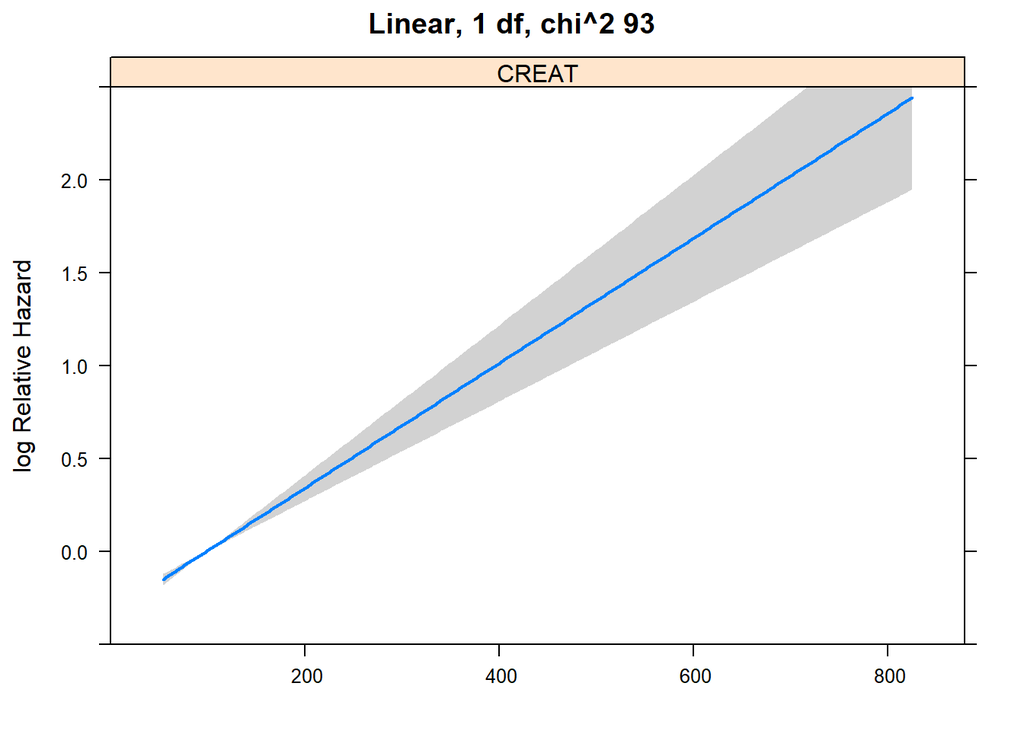

```r
plot(Predict(fit),
     main = paste("Linear, 1 df, ", "chi^2"," ", 93,sep=""),
     xlab="Creatinin (mmol/l)", ylab = "log Relative Hazard",
     lty=1, lwd=2,conf.int=T, ylim=c(-.5, 2.5))
```

```r
# title(substitute(paste("Linear, 1 df, ", chi^2," ", 93,sep="")), cex.main=1.2)

fit <- cph(Surv(TEVENT,EVENT) ~  rcs(CREAT,4), data=SMART)
anova(fit)
```

```
##                 Wald Statistics          Response: Surv(TEVENT, EVENT)
##
##  Factor     Chi-Square d.f. P
##  CREAT      117.19     3    <.0001
##   Nonlinear  43.55     2    <.0001
##  TOTAL      117.19     3    <.0001
```

[figure not shown]

```r
plot(Predict(fit),
     main = paste("Spline, 3 df, ", "chi^2"," ", 116,sep=""),
     xlab="Creatinin (mmol/l)", ylab = "log Relative Hazard",
     lty=3, lwd=2,conf.int=T, ylim=c(-.5, 2.5))
```

```r
# title(substitute(paste("Spline, 3 df, ", chi^2," ", 116,sep="")), cex.main=1.2)

fit <- cph(Surv(TEVENT,EVENT) ~  rcs(CREAT,3), data=SMART)
anova(fit)
```

```
##                 Wald Statistics          Response: Surv(TEVENT, EVENT)
##
##  Factor     Chi-Square d.f. P
##  CREAT      99.75      2    <.0001
##   Nonlinear 20.86      1    <.0001
##  TOTAL      99.75      2    <.0001
```

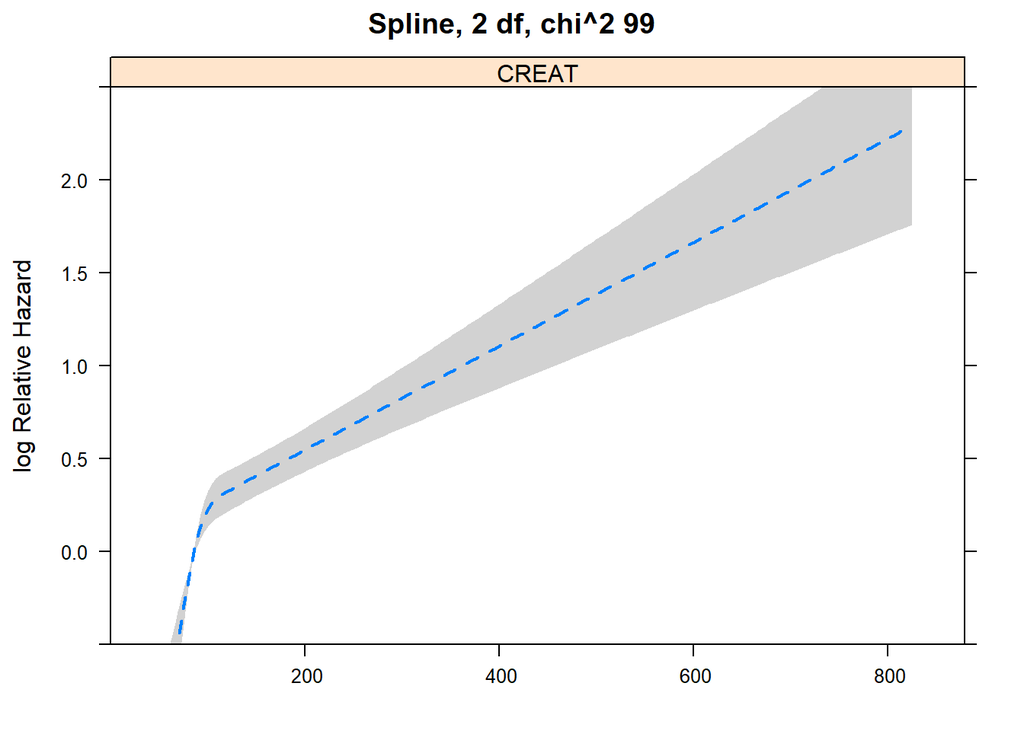

```r
plot(Predict(fit),
     main = paste("Spline, 2 df, ", "chi^2"," ", 99,sep=""),
     xlab="Creatinin (mmol/l)", ylab = "log Relative Hazard",
     lty=2, lwd=2,conf.int=T, ylim=c(-.5, 2.5))
```

```r
# title(substitute(paste("Spline, 2 df, ", chi^2," ", 99,sep="")), cex.main=1.2)

fit <- cph(Surv(TEVENT,EVENT) ~  log(CREAT), data=SMART)
anova(fit)
```

```
##                 Wald Statistics          Response: Surv(TEVENT, EVENT)
##
##  Factor     Chi-Square d.f. P
##  CREAT      132.01     1    <.0001
##  TOTAL      132.01     1    <.0001
```

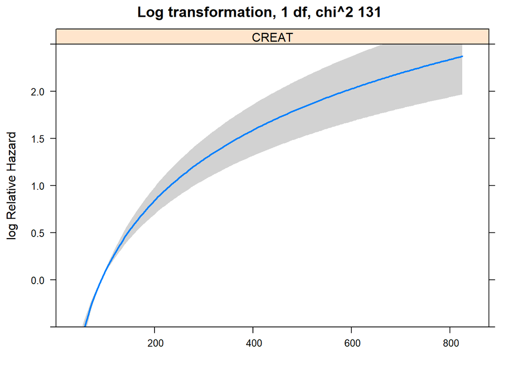

```r
plot(Predict(fit),
     main = paste("Log transformation, 1 df, ", "chi^2"," ", 131,sep=""),
     xlab="Creatinin (mmol/l)", ylab = "log Relative Hazard",
     lty=1, lwd=2,conf.int=T, ylim=c(-.5, 2.5))
```

```r
# title(substitute(paste("Log transformation, 1 df, ", chi^2," ", 131,sep="")), cex.main=1.2)
# Hence: log(CREAT) good choice
```

### Combining predictors with similar effects

Combining predictors with similar effects can be an effective way to limit the degrees of freedom of predictors in a model, but may decrease the model performance.